# Group Assignment 3

Gangyan Liu, Dijia Tang, Chen Chen

12/7/2019

```r
library(rpart.plot)
library(ggplot2)
library(rpart)
library(dplyr)
library(caret)
library(tidyr)
```

# **PART I: Collect the Data**

```r
mush <- read.csv("https://s3.amazonaws.com/notredame.analytics.data/mushrooms.csv")

glimpse(mush)
```

```
## Observations: 8,124
## Variables: 23
## $ type                     <fct> poisonous, edible, edible, poisonous, edib...
## $ cap_shape                <fct> convex, convex, bell, convex, convex, conv...
## $ cap_surface              <fct> smooth, smooth, smooth, scaly, smooth, sca...
## $ cap_color                <fct> brown, yellow, white, white, gray, yellow,...
## $ bruises                  <fct> yes, yes, yes, yes, no, yes, yes, yes, yes...
## $ odor                     <fct> pungent, almond, anise, pungent, none, alm...
## $ gill_attachment          <fct> free, free, free, free, free, free, free, ...
## $ gill_spacing             <fct> close, close, close, close, crowded, close...
## $ gill_size                <fct> narrow, broad, broad, narrow, broad, broad...
## $ gill_color               <fct> black, black, brown, brown, black, brown, ...
## $ stalk_shape              <fct> enlarging, enlarging, enlarging, enlarging...
## $ stalk_root               <fct> equal, club, club, equal, equal, club, clu...
## $ stalk_surface_above_ring <fct> smooth, smooth, smooth, smooth, smooth, sm...
## $ stalk_surface_below_ring <fct> smooth, smooth, smooth, smooth, smooth, sm...
## $ stalk_color_above_ring   <fct> white, white, white, white, white, white, ...
## $ stalk_color_below_ring   <fct> white, white, white, white, white, white, ...
## $ veil_type                <fct> partial, partial, partial, partial, partia...
## $ veil_color               <fct> white, white, white, white, white, white, ...
## $ ring_number              <fct> one, one, one, one, one, one, one, one, on...
## $ ring_type                <fct> pendant, pendant, pendant, pendant, evanes...
## $ spore_print_color        <fct> black, brown, brown, black, brown, black, ...
## $ population               <fct> scattered, numerous, numerous, scattered, ...
## $ habitat                  <fct> urban, grasses, meadows, urban, grasses, g...
```

Change the column name

```r
colnames(mush)[1] <- "edible"
```

Change “poisonous” to “No” and “edible” to "Yes

```r
mush$edible <- as.character(mush$edible)
mush$edible[mush$edible=="poisonous"] <- "No"
mush$edible[mush$edible=="edible"] <- "Yes"
mush$edible <- as.factor(mush$edible)
```

# **PART II: Explore and Prepare the Data**

Check data quality issues – data inbalance by making frequency plots and class distribution table

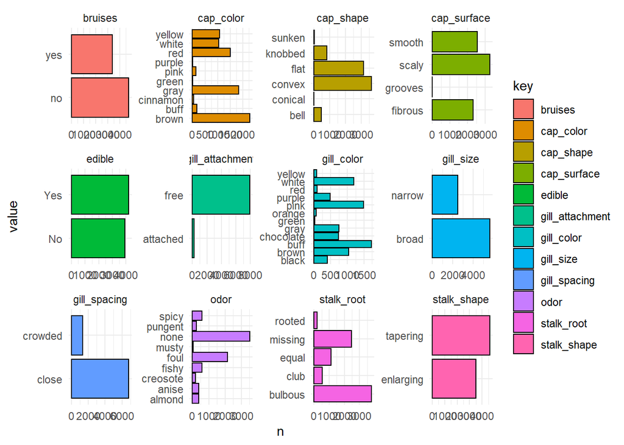

```r
mush[,1:12] %>%
  gather() %>%
  group_by(key,value) %>%
  summarise(n = n()) %>%
  ggplot() +
  geom_bar(mapping=aes(x = value, y = n, fill=key), color="black", stat='identity') +
  coord_flip() +
  facet_wrap(~ key, scales = "free") +
  theme_minimal()
```

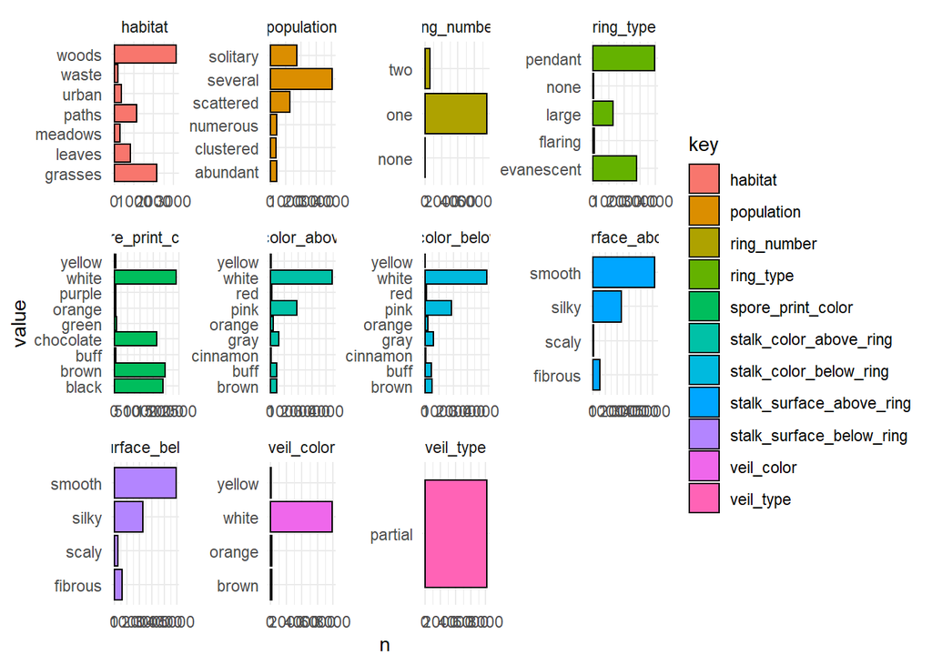

```r
mush[,13:23] %>%
  gather() %>%
  group_by(key,value) %>%
  summarise(n = n()) %>%
  ggplot() +
  geom_bar(mapping=aes(x = value, y = n, fill=key), color="black", stat='identity') +
  coord_flip() +
  facet_wrap(~ key, scales = "free") +
  theme_minimal()
```

```r
mush %>%
  sapply(table) %>%
  sapply(prop.table)
```

```
## $edible
##
##        No       Yes
## 0.4820286 0.5179714
##
## $cap_shape
##
##         bell      conical       convex         flat      knobbed       sunken
## 0.0556376169 0.0004923683 0.4500246184 0.3879862137 0.1019202363 0.0039389463
##
## $cap_surface
##
##      fibrous      grooves        scaly       smooth
## 0.2855736091 0.0004923683 0.3993106844 0.3146233383
##
## $cap_color
##
##       brown        buff    cinnamon        gray       green        pink
## 0.281142294 0.020679468 0.005416051 0.226489414 0.001969473 0.017725258
##      purple         red       white      yellow
## 0.001969473 0.184638109 0.128015756 0.131954702
##
## $bruises
##
##        no       yes
## 0.5844412 0.4155588
##
## $odor
##
##      almond       anise    creosote       fishy        foul       musty
## 0.049236829 0.049236829 0.023633678 0.070901034 0.265878877 0.004431315
##        none     pungent       spicy
## 0.434268833 0.031511571 0.070901034
##
## $gill_attachment
##
##   attached       free
## 0.02584934 0.97415066
##
## $gill_spacing
```

[output cut: 71 more lines]

```
##
##       black       brown        buff   chocolate       green      orange
## 0.230428360 0.242245199 0.005908419 0.200886263 0.008862629 0.005908419
##      purple       white      yellow
## 0.005908419 0.293943870 0.005908419
##
## $population
##
##   abundant  clustered   numerous  scattered    several   solitary
## 0.04726736 0.04185130 0.04923683 0.15361891 0.49729197 0.21073363
##
## $habitat
##
##    grasses     leaves    meadows      paths      urban      waste      woods
## 0.26440177 0.10241260 0.03594289 0.14081733 0.04529788 0.02363368 0.38749385
```

Looking at the above probability tables and visualizations, we can see that our dependent variable is pretty balanced. This indicates that the less balanced binary features would not be good predictors. We can eliminate features that have a small number of levels and are extremely imbalanced.

```r
level <- as.data.frame(lapply(mush, nlevels)) %>%
  pivot_longer(everything(),names_to = 'Predictors',values_to = 'levels')

levels_less_than_median_and_mean <- level[level$levels <= median(level$levels)&level$levels <= mean(level$levels),]

levels_less_than_median_and_mean
```

```
## # A tibble: 12 x 2
##    Predictors               levels
##    <chr>                     <int>
##  1 edible                        2
##  2 cap_surface                   4
##  3 bruises                       2
##  4 gill_attachment               2
##  5 gill_spacing                  2
##  6 gill_size                     2
##  7 stalk_shape                   2
##  8 stalk_surface_above_ring      4
##  9 stalk_surface_below_ring      4
## 10 veil_type                     1
## 11 veil_color                    4
## 12 ring_number                   3
```

We should start by eliminating features with less than or equal to the median and mean of levels and imbalance in the number of observations.

```r
mush_new <- mush %>%
  select(-gill_attachment, -gill_spacing, -gill_size, -cap_surface, -veil_color, -veil_type, -ring_number)
```

Stratified Sampling: 60% for training and 40% for test

```r
set.seed(1234)
sample_set <- createDataPartition(mush_new$edible, p = .6, list = FALSE)
mush_new_train <- mush_new[sample_set, ]
mush_new_test <- mush_new[-sample_set, ]
```

# **Part III:Model selection**

Amongst the available models, we would choose Logistic Regression and Decision Trees.

Why not choosing KNN: KNN involves calculating Euclidean distance, which requires continuous features. We only have categorical features.

Why choose Logistic Regression: 1. Logistic Regression does a better job handling categorical variables than KNN. 2. Logistic Regression is useful in predicting a binomial response. This applies to our case.

Why choose Decision Tree: 1. Decision Trees can ignore unimportant features. 2. Decision Trees handle categorical variables well. 3. The output is easy to understand.

We first use decision tree because it will help us figure out the most predictive predictor.

Check the proportions for the class between all 3 datasets

```r
round(prop.table(table(mush_new$edible)),2)
```

```
##
##   No  Yes
## 0.48 0.52
```

```r
round(prop.table(table(mush_new_train$edible)),2)
```

```
##
##   No  Yes
## 0.48 0.52
```

```r
round(prop.table(table(mush_new_test$edible)),2)
```

```
##
##   No  Yes
## 0.48 0.52
```

Our data is pretty balanced. There is no need to use SMOTE.

Train the model: Decision Tree

```r
tree_mod <-
  rpart(
    edible ~ .,
    method = "class",
    data = mush_new_train,
    control = rpart.control(cp = 0.001)
  )
```

Plot the decision tree

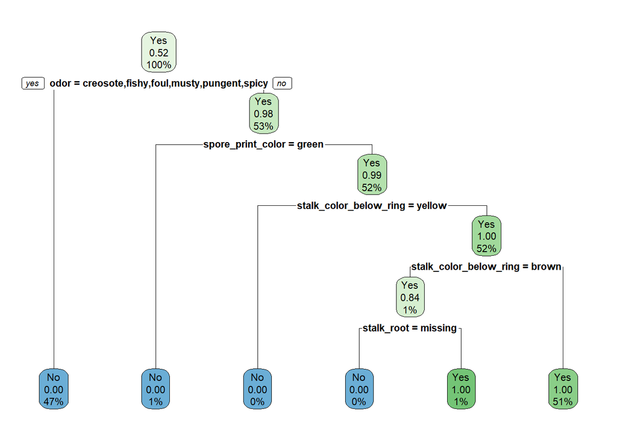

```r
rpart.plot(tree_mod)
```

We can see that according to the decision tree, the most predictive feature is odor. So we use that for our logistic regression.

Train the model: Logistic Regression

```r
logit_mod <-
  glm(edible ~ odor, family = binomial(link = 'logit'), data = mush_new_train)

summary(logit_mod)
```

```
##
## Call:
## glm(formula = edible ~ odor, family = binomial(link = "logit"),
##     data = mush_new_train)
##
## Deviance Residuals:
##      Min        1Q    Median        3Q       Max
## -2.64264  -0.00003   0.00003   0.24868   0.24868
##
## Coefficients:
##                Estimate Std. Error z value Pr(>|z|)
## (Intercept)   2.157e+01  1.883e+03   0.011    0.991
## odoranise    -2.714e-09  2.649e+03   0.000    1.000
## odorcreosote -4.313e+01  3.343e+03  -0.013    0.990
## odorfishy    -4.313e+01  2.432e+03  -0.018    0.986
## odorfoul     -4.313e+01  2.050e+03  -0.021    0.983
## odormusty    -4.313e+01  7.143e+03  -0.006    0.995
## odornone     -1.811e+01  1.883e+03  -0.010    0.992
## odorpungent  -4.313e+01  2.970e+03  -0.015    0.988
## odorspicy    -4.313e+01  2.471e+03  -0.017    0.986
##
## (Dispersion parameter for binomial family taken to be 1)
##
##     Null deviance: 6751.90  on 4874  degrees of freedom
## Residual deviance:  572.98  on 4866  degrees of freedom
## AIC: 590.98
##
## Number of Fisher Scoring iterations: 20
```

# **PART IV: Evaluate the Performance of the Models**

Predictions – Decision Tree

```r
tree_pred <- predict(tree_mod, mush_new_test, type = "class")

head(tree_pred)
```

```
##   1   3   8   9  11  13
##  No Yes Yes  No Yes Yes
## Levels: No Yes
```

Construct confusion matrix – Decision Tree

```r
tree_pred_table <- table(mush_new_test$edible, tree_pred)
tree_pred_table
```

```
##      tree_pred
##         No  Yes
##   No  1561    5
##   Yes    0 1683
```

Check accuracy of this Decision Tree model

```r
tree_pred_accuracy <- sum(diag(tree_pred_table)) / nrow(mush_new_test)
tree_pred_accuracy
```

```
## [1] 0.9984611
```

Predictions – Logistic Regression

```r
logit_pred <- predict(logit_mod, mush_new_test, type = 'response')
head(logit_pred)
```

```
##            1            3            8            9           11           13
## 4.305023e-10 1.000000e+00 1.000000e+00 4.305023e-10 1.000000e+00 1.000000e+00
```

```r
logit_pred <- ifelse(logit_pred > 0.5, "Yes", "No")
head(logit_pred)
```

```
##     1     3     8     9    11    13
##  "No" "Yes" "Yes"  "No" "Yes" "Yes"
```

Construct confusion matrix – Logistic Regression

```r
logit_pred_table <- table(mush_new_test$edible, logit_pred)
logit_pred_table
```

```
##      logit_pred
##         No  Yes
##   No  1510   56
##   Yes    0 1683
```

Check accuracy of this Logistic Regression model

```r
sum(diag(logit_pred_table)) / nrow(mush_new_test)
```

```
## [1] 0.9827639
```